# Multi-armed Bandit Learning

- Author: **陈昱聪**
- Student ID: **2019533079**
- Email: *chenyc@shanghaitech.edu.cn*
- School: **SIST**

## Abstract and Contents

In probability theory, the multi-armed bandit problem (sometimes called the K- or N-armed bandit problem) is a problem in which a fixed limited set of resources must be allocated between competing (alternative) choices in a way that maximizes their expected gain, when each choice's properties are only partially known at the time of allocation, and may become better understood as time passes or by allocating resources to the choice. This is a classic reinforcement learning problem that exemplifies the exploration–exploitation tradeoff dilemma. The name comes from imagining a gambler at a row of slot machines (sometimes known as "one-armed bandits"), who has to decide which machines to play, how many times to play each machine and in which order to play them, and whether to continue with the current machine or try a different machine. The multi-armed bandit problem also falls into the broad category of stochastic scheduling.[3]

In the problem, each machine provides a random reward from a probability distribution specific to that machine. The objective of the gambler is to maximize the sum of rewards earned through a sequence of lever pulls.The crucial tradeoff the gambler faces at each trial is between "exploitation" of the machine that has the highest expected payoff and "exploration" to get more information about the expected payoffs of the other machines.[3]

Here, I'm going to analyze three algorithms of Multi-armed Bandit Learning, and I will expand it according to the following structure:

- ### Settings
- ### 𝜖 -Greedy Algorithm
  - #### The results of 𝜖− Greedy Algorithm
- ### UCB Algorithm
  - #### The results of UCB Algorithm
- ### Thompson Sampling Algorithm
  - #### The results of Thompson Sampling Algorithm
- ### Comparison, Conclusion and Further Discussion
- ### References

##### Note: It may take a fairly long time if you choose to rerun these codes.

## Settings

```python
import numpy as np
import random
import matplotlib.pyplot as plt
import seaborn as sns
from tqdm.notebook import tqdm
from scipy.interpolate import interp1d
from matplotlib import cm
from matplotlib.ticker import LinearLocator



plt.style.use('ggplot')
sns.set_style("white")


font1 = {'family': 'serif',
        'color':  'darkred',
        'weight': 'normal',
        'size': 12,
        }

font2 = {'family': 'serif',
        'color':  'dodgerblue',
        'weight': 'normal',
        'size': 12,
        }

colors1 = '#DC143C'
colors2 = '#00CED1'
```

- True values of the three parameters, which are all independent from each other.

| Arm $j$ | 1 | 2 | 3 |
| --- | --- | --- | --- |
| $\theta_j$ | 0.9 | 0.8 | 0.7 |

- The number of rounds in one experiment $N = 5000$
- All results are based on the average data of 200 experiments, unless otherwise noted.

```python
######################################### God Knows #########################################
N = 5000

experimentNum = 200

theta = np.tile(np.array([0.9, 0.8, 0.7]), (N, 1))

def new_expire():
    global judge
    judge = np.random.rand(N, 3) < theta
    judge = judge.astype(np.int64)

new_expire()

# give you reward ($0 or $1)
def reward(rounds : int, I : int):
    return judge[rounds][I]

######################################### God Knows #########################################
```

```python
def experiment(x_params : np.ndarray, OBJ):
    obj = np.array([])

    if OBJ == TS_fixed:
        for i in range(x_params[0], x_params[1], x_params[-1]):
            for j in range(x_params[2], x_params[3], x_params[-1]):
                obj = np.append(obj, OBJ(np.array([i,i,i,j,j,j])))
        rewards = np.zeros((len(obj), N))
        for i in tqdm(range(experimentNum)):
            for j in range(len(obj)):
                rewards[j] += obj[j].play()
        return (np.sum(rewards, axis = 1) / experimentNum).reshape(np.arange(x_params[0], x_params[1], x_params[-1]).shape[0], np.arange(x_params[2], x_params[3], x_params[-1]).shape[0])


    elif OBJ == epsilon_Greedy:
        params = np.tile(x_params, (N, 1))
        for i in range(len(x_params)):
            obj = np.append(obj, OBJ(params[:, i]))

    elif OBJ == TS:
        for i in range(x_params.shape[0]):

                obj = np.append(obj, OBJ(x_params[i]))

    elif OBJ == UCB:
        for i in range(len(x_params)):
            obj = np.append(obj, OBJ(x_params[i]))


    rewards = np.zeros((len(obj), N, experimentNum))
    regret = np.zeros((len(obj), N, experimentNum))
    opt_choice = np.zeros((len(obj), N, experimentNum))

    for i in tqdm(range(experimentNum)):
        for j in range(len(obj)):
            a, b, c= obj[j].play()
            rewards[j, :, i] = a
            regret[j, :, i] = b
            opt_choice[j, :, i] = c

    rewards = np.cumsum(rewards, axis = 1)
    regret = np.cumsum(regret, axis = 1)
    opt_choice = np.cumsum(opt_choice, axis = 1)

    x_rounds = np.arange(1, N+1)

    prop_po_rewards = np.percentile(rewards / np.tile(x_rounds*max(theta[0]), (experimentNum, 1)).T, [25, 75], axis = 2)
    prop_po_opt_choice = np.percentile(opt_choice / np.tile(x_rounds, (experimentNum, 1)).T, [25, 75], axis = 2)


    rewards = np.sum(rewards, axis = 2) / experimentNum
    regret = np.sum(regret, axis = 2) / experimentNum
    opt_choice = np.sum(opt_choice, axis = 2) / experimentNum

    prop_opt_choice = opt_choice / x_rounds
    prop_rewards = rewards / (x_rounds*max(theta[0]))

    return rewards, regret, opt_choice, x_rounds, prop_po_rewards, prop_po_opt_choice
```

## $\epsilon$-Greedy Algorithm

$\epsilon$-Greedy Algorithm is the most direct and intuitive algorithm for exploration-exploitation. It selects a specific small constant $\epsilon$ as the probability of its choice for exploration, and the rest for exploitation.

```python
class epsilon_Greedy():

    #Initialize
    def __init__(self, epsilon : np.ndarray):
        new_expire()
        self.theta_hat = [0, 0, 0]
        self.count = [0, 0, 0]
        self.rewards = np.zeros(N)
        self.regret = np.zeros(N)
        self.opt_choice = np.zeros(N)
        self.epsilon = epsilon
        self.explor = np.random.rand(len(epsilon)) < self.epsilon


    # decide if we gonna exploration
    def exploration(self, rounds : int):
        return self.explor[rounds]


    # return the j where theta_hat[j] reaches the max
    # if there are more than one arg_max j, then randomly choose one
    def maxVal_index(self):
        return random.choice([i for i in range(3) if self.theta_hat[i] == max(self.theta_hat)])


    # determine which arm we gonna pull
    def pull(self, rounds : int):
        return random.choice([0, 1, 2]) if self.exploration(rounds) else self.maxVal_index()


    # repeatedly pull to play the game
    def play(self):
        self.__init__(self.epsilon)
        for i in range(N):
            I = self.pull(i)
            self.count[I] += 1
            r = reward(i, I)
            self.rewards[i] = r
            self.regret[i] = max(theta[0, :]) - theta[0, I]
            self.opt_choice[i] = (np.argmax(theta[0, :]) == I)
            self.theta_hat[I] += ((1/self.count[I]) * (r - self.theta_hat[I]))

        return self.rewards, self.regret, self.opt_choice
```

### The results of $\epsilon-$Greedy Algorithm

```python
x1_epsilon = np.array([0, 0.005, 0.01, 0.02, 0.03, 0.045, 0.06, 0.08, 0.1, 0.12, 0.15, 0.2, 0.25, 0.3, 0.4, 0.5, 0.6, 0.7, 0.8, 0.9, 1])

rewards1, regret1, opt_choice1, x_rounds1, prop_po_rewards1, prop_po_opt_choice1 = experiment(x1_epsilon, epsilon_Greedy)
```

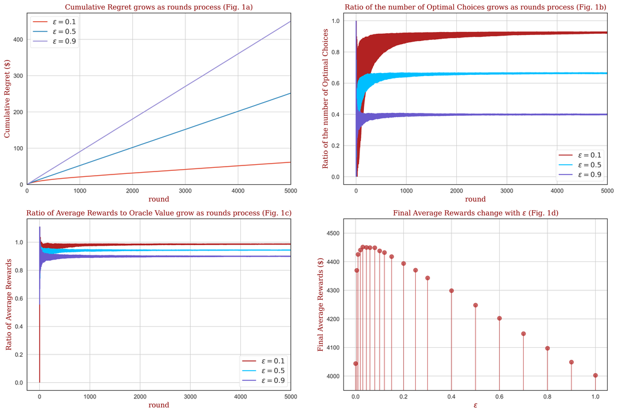

```python
fig1, ax1 = plt.subplots(2, 2, figsize=(18,12), dpi = 400)

ax1_1 = ax1[0][0]
ax1_2 = ax1[0][1]
ax1_3 = ax1[1][0]
ax1_4 = ax1[1][1]

ax1_1.plot(x_rounds1, regret1[8])
ax1_1.plot(x_rounds1, regret1[15])
ax1_1.plot(x_rounds1, regret1[19])
ax1_1.axis(ymin = 0, xmax = 5000, xmin = 0)
ax1_1.set_title('Cumulative Regret grows as rounds process (Fig. 1a)', fontdict=font1)
ax1_1.set_xlabel('round', fontdict=font1)
ax1_1.set_ylabel('Cumulative Regret ($)', fontdict=font1)

ax1_2.vlines(x=x_rounds1, ymin = prop_po_opt_choice1[0, 8], ymax=prop_po_opt_choice1[1, 8], color='firebrick')
ax1_2.vlines(x=x_rounds1, ymin = prop_po_opt_choice1[0, 15], ymax=prop_po_opt_choice1[1, 15], color='deepskyblue')
ax1_2.vlines(x=x_rounds1, ymin = prop_po_opt_choice1[0, 19], ymax=prop_po_opt_choice1[1, 19], color='slateblue')
ax1_2.axis(xmax = 5000)
ax1_2.set_title('Ratio of the number of Optimal Choices grows as rounds process (Fig. 1b)', fontdict=font1)
ax1_2.set_xlabel('round', fontdict=font1)
ax1_2.set_ylabel('Ratio of the number of Optimal Choices', fontdict=font1)

ax1_3.vlines(x=x_rounds1, ymin = prop_po_rewards1[0, 8], ymax=prop_po_rewards1[1, 8], color='firebrick')
ax1_3.vlines(x=x_rounds1, ymin = prop_po_rewards1[0, 15], ymax=prop_po_rewards1[1, 15], color='deepskyblue')
ax1_3.vlines(x=x_rounds1, ymin = prop_po_rewards1[0, 19], ymax=prop_po_rewards1[1, 19], color='slateblue')
ax1_3.axis(xmax = 5000)
ax1_3.set_title('Ratio of Average Rewards to Oracle Value grow as rounds process (Fig. 1c)', fontdict=font1)
ax1_3.set_xlabel('round', fontdict=font1)
ax1_3.set_ylabel('Ratio of Average Rewards', fontdict=font1)

ax1_1.legend((r'$\epsilon = 0.1$',r'$\epsilon = 0.5$',r'$\epsilon = 0.9$'), loc='best', fontsize = 'large')
ax1_2.legend((r'$\epsilon = 0.1$',r'$\epsilon = 0.5$',r'$\epsilon = 0.9$'), loc='lower right', fontsize = 'large')
ax1_3.legend((r'$\epsilon = 0.1$',r'$\epsilon = 0.5$',r'$\epsilon = 0.9$'), loc='lower right', fontsize = 'large')
ax1_1.grid()
ax1_2.grid()
ax1_3.grid()
ax1_4.grid()

ax1_4.scatter(x1_epsilon, rewards1[:, -1], s=55, color='firebrick', alpha=0.7)
ax1_4.axis(ymin = 3950, ymax = 4550)
ax1_4.vlines(x=x1_epsilon, ymin=3950, ymax=rewards1[:, -1], color='firebrick', alpha=0.7, linewidth=1)
ax1_4.set_title(r'Final Average Rewards change with $\epsilon$ (Fig. 1d)', fontdict=font1)
ax1_4.set_xlabel(r'$\epsilon$', fontdict=font1)
ax1_4.set_ylabel('Final Average Rewards ($)', fontdict=font1)

plt.show()
```

#### (Fig. 1a): How does Cumulative Regret *(the cumulative gaps between 'max($\theta$)' and the chosen '$\theta$')* grow as rounds process with different $\epsilon s$?

As the data shown in Fig. 1a, the Cumulative Regrets approximate **linear growth**. The slope with $\epsilon = 0.1$ is the smallest, which should be the best of the three.

#### (Fig. 1b): How does the ratio of the number of Optimal Choices grow as rounds process with different $\epsilon s$?

In At the beginning, the ratio was very unstable, but the overall trend was growth and stabilization. The growth with $\epsilon = 0.1$ is the fastest, which should be the best of the three (while the growth with $\epsilon = 0.9$ seems to stay in its place at the very beginning, which is bad).

#### (Fig. 1c): How does the ratio of Average Rewards to Oracle Value grow as rounds process with different $\epsilon s$?

At the beginning, the ratio was very unstable, but the overall trend was stabilization and stay in certain value. The stable ratio with $\epsilon = 0.1$ is the highest, which should be the best of the three

#### (Fig. 1d): How do the Final Average Rewards change as $\epsilon$ increases from $0$ to $1$ ?

As we have seen, from 0 to 0.03, the Average Rewards rises very sharply and reaches to the maximum, then it start to drop. According to the figure, the optimal $\epsilon$ might be around $0.03$.

#### Result gaps:

Final Average Rewards($\epsilon = 0.1$) = 4437.92

Gap($\epsilon = 0.1$) = 62.08

Final Average Rewards($\epsilon = 0.5$) = 4248.075

Gap($\epsilon = 0.5$) = 251.925

Final Average Rewards($\epsilon = 0.9$) = 4049.095

Gap($\epsilon = 0.9$) = 450.905

## UCB Algorithm

```python
class UCB():

    #Initialize
    def __init__(self, c):
        new_expire()
        self.theta_hat = [reward(0, 0), reward(0, 1), reward(0, 2)]
        self.count = [1, 1, 1]

        self.rewards = np.zeros(N)
        self.rewards[:3] = self.theta_hat.copy()

        self.regret = np.zeros(N)

        self.regret[:3] = np.array([max(theta[0, :]) - theta[0, 0], max(theta[0, :]) - theta[0, 1], max(theta[0, :]) - theta[0, 2]])

        self.opt_choice = np.zeros(N)
        self.opt_choice[:3] = np.array([np.argmax(theta[0, :]) == 0, np.argmax(theta[0, :]) == 1, np.argmax(theta[0, :]) == 2])

        self.c = c


    def pull(self, t : int):

        M = max(self.theta_hat + self.c*np.sqrt((2*np.log(t))/(self.count)))
        return random.choice([index for index in range(3) if (self.theta_hat[index] + self.c*np.sqrt((2*np.log(t))/(self.count[index]))) == M])

    # repeatedly pull to play the game
    def play(self):

        self.__init__(self.c)

        for i in range(3, N):
            I = self.pull(i)
            self.count[I] += 1
            r = reward(i, I)
            self.rewards[i] += r
            self.regret[i] = max(theta[0, :]) - theta[0, I]
            self.opt_choice[i] = (np.argmax(theta[0, :]) == I)
            self.theta_hat[I] += ((1/self.count[I]) * (r - self.theta_hat[I]))

        return self.rewards, self.regret, self.opt_choice
```

```python
x2_c = np.array([0, 0.15, 0.3, 0.65, 1, 1.5, 2.2, 3, 4, 5, 6.5, 8, 10])

rewards2, regret2, opt_choice2, x_rounds2, prop_po_rewards2, prop_po_opt_choice2 = experiment(x2_c, UCB)
```

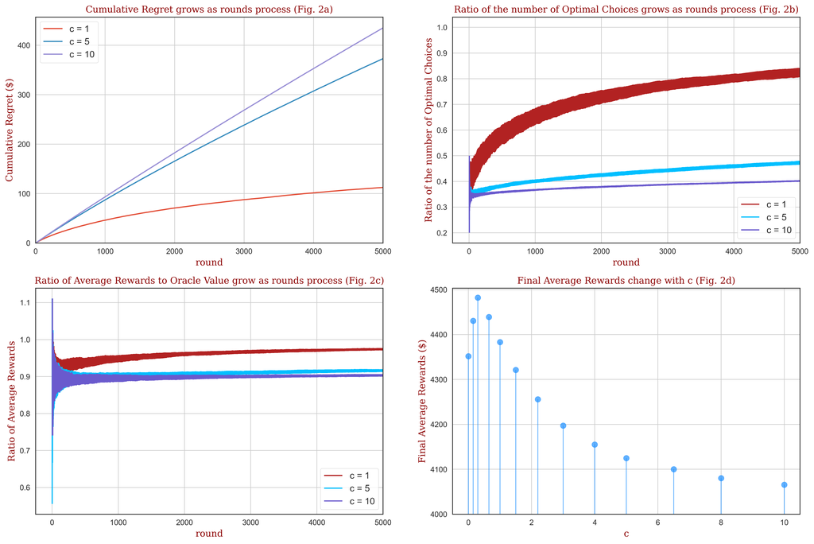

```python
fig2, ax2 = plt.subplots(2, 2, figsize=(18,12), dpi = 400)

ax2_1 = ax2[0][0]
ax2_2 = ax2[0][1]
ax2_3 = ax2[1][0]
ax2_4 = ax2[1][1]

ax2_1.plot(x_rounds2, regret2[4])
ax2_1.plot(x_rounds2, regret2[9])
ax2_1.plot(x_rounds2, regret2[12])
ax2_1.axis(ymin = 0, xmax = 5000, xmin = 0)
ax2_1.set_title('Cumulative Regret grows as rounds process (Fig. 2a)', fontdict=font1)
ax2_1.set_xlabel('round', fontdict=font1)
ax2_1.set_ylabel('Cumulative Regret ($)', fontdict=font1)


ax2_2.vlines(x=x_rounds2, ymin = prop_po_opt_choice2[0, 4], ymax=prop_po_opt_choice2[1, 4], color='firebrick')
ax2_2.vlines(x=x_rounds2, ymin = prop_po_opt_choice2[0, 9], ymax=prop_po_opt_choice2[1, 9], color='deepskyblue')
ax2_2.vlines(x=x_rounds2, ymin = prop_po_opt_choice2[0, 12], ymax=prop_po_opt_choice2[1, 12], color='slateblue')
ax2_2.axis(xmax = 5000)
ax2_2.set_title('Ratio of the number of Optimal Choices grows as rounds process (Fig. 2b)', fontdict=font1)
ax2_2.set_xlabel('round', fontdict=font1)
ax2_2.set_ylabel('Ratio of the number of Optimal Choices', fontdict=font1)

ax2_3.vlines(x=x_rounds2, ymin = prop_po_rewards2[0, 4], ymax=prop_po_rewards2[1, 4], color='firebrick')
ax2_3.vlines(x=x_rounds2, ymin = prop_po_rewards2[0, 9], ymax=prop_po_rewards2[1, 9], color='deepskyblue')
ax2_3.vlines(x=x_rounds2, ymin = prop_po_rewards2[0, 12], ymax=prop_po_rewards2[1, 12], color='slateblue')
ax2_3.axis(xmax = 5000)
ax2_3.set_title('Ratio of Average Rewards to Oracle Value grow as rounds process (Fig. 2c)', fontdict=font1)
ax2_3.set_xlabel('round', fontdict=font1)
ax2_3.set_ylabel('Ratio of Average Rewards', fontdict=font1)

ax2_1.legend(('c = 1','c = 5','c = 10'), loc='best', fontsize = 'large')
ax2_2.legend(('c = 1','c = 5','c = 10'), loc='lower right', fontsize = 'large')
ax2_3.legend(('c = 1','c = 5','c = 10'), loc='lower right', fontsize = 'large')
ax2_1.grid()
ax2_2.grid()
ax2_3.grid()
ax2_4.grid()

ax2_4.scatter(x2_c, rewards2[:, -1], s=55, color='dodgerblue', alpha=0.7)
ax2_4.axis(ymin = 4000)
ax2_4.vlines(x=x2_c, ymin=4000, ymax=rewards2[:, -1], color='dodgerblue', alpha=0.7, linewidth=1)
ax2_4.set_title('Final Average Rewards change with c (Fig. 2d)', fontdict=font1)
ax2_4.set_xlabel('c', fontdict=font1)
ax2_4.set_ylabel('Final Average Rewards ($)', fontdict=font1)

plt.show()
```

#### (Fig. 2a): How does Cumulative Regret *(the cumulative gaps between 'max($\theta$)' and the chosen '$\theta$')* grow as rounds process with different c?

Its growth curve is a concave function. It can be seen that when $c = 1$, the slope of the curve is the smallest, and the degree of the curve is the largest, and the growth tends to be gentle, which is the best among the three.

#### (Fig. 2b): How does the ratio of the number of Optimal Choices grow as rounds process with different c?

In At the beginning, the ratio was unstable, but the overall trend was growth and stabilization. The growth with $c = 1$ is the fastest, which should be the best of the three.

#### (Fig. 2c): How does the ratio of Average Rewards to Oracle Value grow as rounds process with different c?

At the beginning, the ratio was very unstable, but the overall trend was stabilization and stay in certain value. The stable ratio with $c = 1$ is the highest, which should be the best of the three.

#### (Fig. 2d): How do the Final Average Rewards change as c increases from $0$ to $10$ ?

As we have seen, from 0 to 0.3, the Average Rewards rises and reaches to the maximum, then it start to drop. According to the figure, the optimal $c$ might be around $0.3$.

#### Result gaps:

Final Average Rewards($c = 1$) = 4383.11

Gap($c = 1$) = 116.89

Final Average Rewards($c = 5$) = 4124.66

Gap($c = 5$) = 375.34

Final Average Rewards($c = 10$) = 4065.495

Gap($c = 10$) = 434.505

## Thompson Sampling Algorithm

```python
class TS():
    #Initialize
    def __init__(self, prior : np.ndarray):

        new_expire()
        self.theta_hat = [0, 0, 0]
        self.prior_original = prior
        self.prior = prior.copy()
        self.rewards = np.zeros(N)
        self.regret = np.zeros(N)
        self.opt_choice = np.zeros(N)


    def pull(self):
        return random.choice([i for i in range(3) if self.theta_hat[i] == max(self.theta_hat)])

    def update(self):
        self.theta_hat = [np.random.beta(self.prior[i], self.prior[3+i]) for i in range(3) if True]


    def play(self):

        self.__init__(self.prior_original)

        for i in range(N):
            self.update()
            I = self.pull()
            r = reward(i, I)
            self.prior[I] += r
            self.prior[3+I] += (1 - r)
            self.rewards[i] += r
            self.regret[i] = max(theta[0, :]) - theta[0, I]
            self.opt_choice[i] = (np.argmax(theta[0, :]) == I)

        return  self.rewards, self.regret, self.opt_choice

class TS_fixed():
    #Initialize
    def __init__(self, prior : np.ndarray):

        new_expire()
        self.theta_hat = [0, 0, 0]
        self.prior_original = prior
        self.prior = prior.copy()
        self.rewards = np.zeros(N)


    def pull(self):
        return random.choice([i for i in range(3) if self.theta_hat[i] == max(self.theta_hat)])

    def update(self):
        self.theta_hat = [np.random.beta(self.prior[i], self.prior[3+i]) for i in range(3) if True]


    def play(self):

        self.__init__(self.prior_original)

        for i in range(N):
            self.update()
            I = self.pull()
            r = reward(i, I)
            self.prior[I] += r
            self.prior[3+I] += (1 - r)
            self.rewards[i] = r


        return  self.rewards
```

```python
x3_prior_fixed = [1, 150, 1, 300, 15]
x3_fixedprior_alpha = np.arange(1, 150, 15)
x3_fixedprior_beta = np.arange(1, 300, 15)
x3_fixedprior_alpha, x3_fixedprior_beta = np.meshgrid(x3_fixedprior_alpha, x3_fixedprior_beta)
rewards3_fixed = experiment(x3_prior_fixed, TS_fixed)


x3_prior = np.array([[1,1,1,1,1,1], [50000, 50000, 50000, 50000, 50000, 50000], [601,401,2,401,601,3]])
rewards3, regret3, opt_choice3, x_rounds3, prop_po_rewards3, prop_po_opt_choice3 = experiment(x3_prior, TS)
```

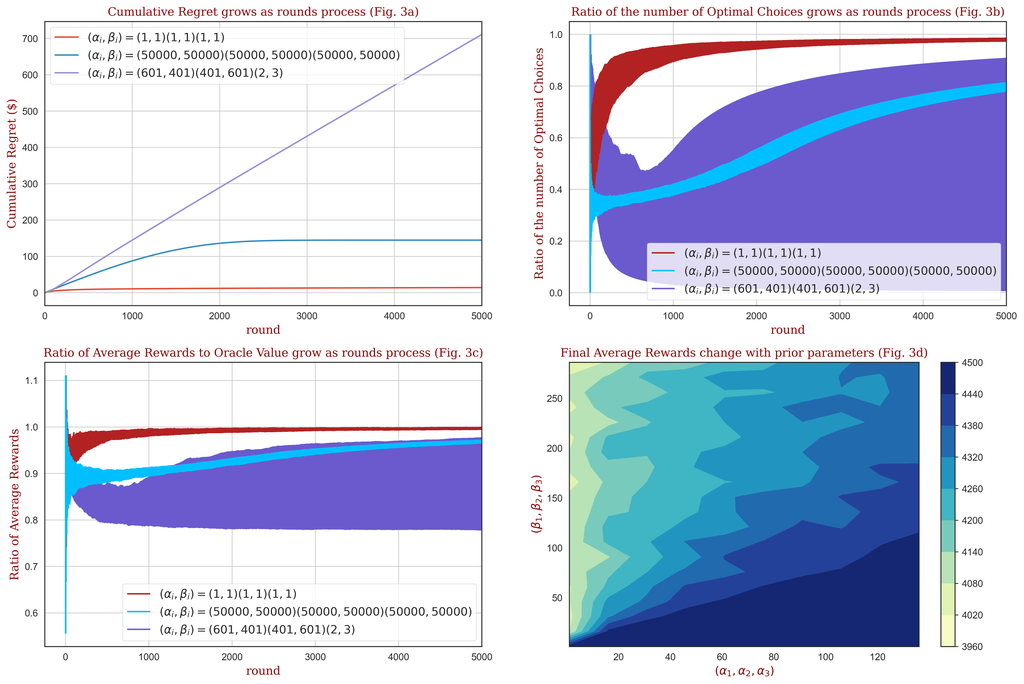

```python
fig3, ax3 = plt.subplots(2, 2, figsize=(18,12), dpi = 400)

ax3_1 = ax3[0][0]
ax3_2 = ax3[0][1]
ax3_3 = ax3[1][0]
ax3_4 = ax3[1][1]

ax3_1.plot(x_rounds3, regret3[0])
ax3_1.plot(x_rounds3, regret3[1])
ax3_1.plot(x_rounds3, regret3[2])
ax3_1.axis(xmax = 5000, xmin = 0)
ax3_1.set_title('Cumulative Regret grows as rounds process (Fig. 3a)', fontdict=font1)
ax3_1.set_xlabel('round', fontdict=font1)
ax3_1.set_ylabel('Cumulative Regret ($)', fontdict=font1)

ax3_2.vlines(x=x_rounds3, ymin = prop_po_opt_choice3[0, 0], ymax=prop_po_opt_choice3[1, 0], color='firebrick')
ax3_2.vlines(x=x_rounds3, ymin = prop_po_opt_choice3[0, 1], ymax=prop_po_opt_choice3[1, 1], color='deepskyblue')
ax3_2.vlines(x=x_rounds3, ymin = prop_po_opt_choice3[0, 2], ymax=prop_po_opt_choice3[1, 2], color='slateblue')
ax3_2.vlines(x=x_rounds3, ymin = prop_po_opt_choice3[0, 0], ymax=prop_po_opt_choice3[1, 0], color='firebrick')
ax3_2.vlines(x=x_rounds3, ymin = prop_po_opt_choice3[0, 1], ymax=prop_po_opt_choice3[1, 1], color='deepskyblue')
ax3_2.axis(xmax = 5000)
ax3_2.set_title('Ratio of the number of Optimal Choices grows as rounds process (Fig. 3b)', fontdict=font1)
ax3_2.set_xlabel('round', fontdict=font1)
ax3_2.set_ylabel('Ratio of the number of Optimal Choices', fontdict=font1)

ax3_3.vlines(x=x_rounds3, ymin = prop_po_rewards3[0, 0], ymax=prop_po_rewards3[1, 0], color='firebrick')
ax3_3.vlines(x=x_rounds3, ymin = prop_po_rewards3[0, 1], ymax=prop_po_rewards3[1, 1], color='deepskyblue')
ax3_3.vlines(x=x_rounds3, ymin = prop_po_rewards3[0, 2], ymax=prop_po_rewards3[1, 2], color='slateblue')
ax3_3.vlines(x=x_rounds3, ymin = prop_po_rewards3[0, 0], ymax=prop_po_rewards3[1, 0], color='firebrick')
ax3_3.vlines(x=x_rounds3, ymin = prop_po_rewards3[0, 1], ymax=prop_po_rewards3[1, 1], color='deepskyblue')
ax3_3.axis(xmax = 5000)
ax3_3.set_title('Ratio of Average Rewards to Oracle Value grow as rounds process (Fig. 3c)', fontdict=font1)
ax3_3.set_xlabel('round', fontdict=font1)
ax3_3.set_ylabel('Ratio of Average Rewards', fontdict=font1)

ax3_1.legend((r'$(\alpha_i, \beta_i) = (1, 1) (1, 1) (1, 1)$', r'$(\alpha_i, \beta_i) = (50000, 50000) (50000, 50000) (50000, 50000)$', r'$(\alpha_i, \beta_i) = (601, 401) (401, 601) (2, 3)$'), loc='best', fontsize = 'large')
ax3_2.legend((r'$(\alpha_i, \beta_i) = (1, 1) (1, 1) (1, 1)$', r'$(\alpha_i, \beta_i) = (50000, 50000) (50000, 50000) (50000, 50000)$', r'$(\alpha_i, \beta_i) = (601, 401) (401, 601) (2, 3)$'), loc='lower right', fontsize = 'large')
ax3_3.legend((r'$(\alpha_i, \beta_i) = (1, 1) (1, 1) (1, 1)$', r'$(\alpha_i, \beta_i) = (50000, 50000) (50000, 50000) (50000, 50000)$', r'$(\alpha_i, \beta_i) = (601, 401) (401, 601) (2, 3)$'), loc='lower right', fontsize = 'large')

ax3_1.grid()
ax3_2.grid()
ax3_3.grid()

cs = ax3_4.contourf(x3_fixedprior_alpha, x3_fixedprior_beta, rewards3_fixed.T, cmap=plt.get_cmap('YlGnBu'))
fig3.colorbar(cs)
ax3_4.set_title('Final Average Rewards change with prior parameters (Fig. 3d)', fontdict=font1)
ax3_4.set_xlabel(r'$(\alpha_1, \alpha_2, \alpha_3)$', fontdict=font1)
ax3_4.set_ylabel(r'$(\beta_1, \beta_2, \beta_3)$', fontdict=font1)

plt.show()
```

#### (Fig. 3a): How does Cumulative Regret *(the cumulative gaps between 'max($\theta$)' and the chosen '$\theta$')* grow as rounds process with different prior parameters?

Its growth curve is a concave function. It can be seen that when all $\alpha_i =\beta_i = 1$, it's almost close to the x-axis without significant growth, which is the best. While we can see the worst case, it almost becomes to linearly grow.

#### (Fig. 3b): How does the ratio of the number of Optimal Choices grow as rounds process with different prior parameters?

We can see that both the first and the second cases experienced growth and tended to converge. In the third case, it becomes very unstable, with values spread over large areas, so obviously it does not converge. The best case is the first one.

#### (Fig. 3c): How does the ratio of Average Rewards to Oracle Value grow as rounds process with different prior parameters?

Same as above. We can see that both the first and the second cases experienced growth and tended to converge. In the third case, it becomes very unstable, with values spread over large areas, so obviously it does not converge. The best case is the first one.

#### (Fig. 3d): How do the Final Average Rewards change as $\alpha$ and $\beta$ take different values? (Because the player cannot distinguish the difference between different arms, we should keep the prior parameters of all arms consistent.)

From the graph, we know it is better to choose larger $\alpha$ and smaller $\beta$. actually, it is ok to choose the same $\alpha$ with $\beta$ when they are both small. We know the smaller their values are, the more uncertainty we have. So if we are not sure, we can pick small prior parameters like $(1, 1)$.

#### Result gaps:

Final Average Rewards$((\alpha, \beta) = (1, 1), (1, 1), (1, 1))$ = 4486.0

Gap$((\alpha, \beta) = (1, 1), (1, 1), (1, 1))$ = 14.0

Final Average Rewards$((\alpha, \beta) = (50000, 50000), (50000, 50000), (50000, 50000))$ = 4357.08

Gap$((\alpha, \beta) = (50000, 50000), (50000, 50000), (50000, 50000))$ = 142.92

Gap$((\alpha, \beta) = (601, 401), (401, 601), (2, 3))$ = 712.535 (Unstable)

## Comparison, Conclusion and Further Discussion

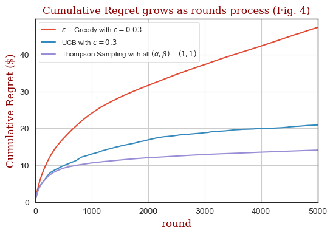

```python
fig4, ax4 = plt.subplots(figsize=(6,4), dpi = 100)

ax4.plot(x_rounds1, regret1[4])
ax4.plot(x_rounds2, regret2[2])
ax4.plot(x_rounds3, regret3[0])

ax4.axis(xmax = 5000, xmin = 0, ymin =0)
ax4.set_title('Cumulative Regret grows as rounds process (Fig. 4)', fontdict=font1)
ax4.set_xlabel('round', fontdict=font1)
ax4.set_ylabel('Cumulative Regret ($)', fontdict=font1)
ax4.legend((r'$\epsilon-$Greedy with $\epsilon = 0.03$', r'UCB with $c = 0.3$', r'Thompson Sampling with all $(\alpha, \beta) = (1, 1)$'), loc='upper left', fontsize = 'small')

ax4.grid()

plt.show()
```

### Q1: which one is better?

I choose some parameters that are likely to make these algorithms optimal. It turns out the Thompson Sampling is the best algorithm since the regret it generates is the smallest and it has the lowest growth. And the $\epsilon-$Greedy is the worst.

### Q2: How to realize the exploration–exploitation tradeoff?

The key point is to hold the dynamic balance of exploration–exploitation.

The $\epsilon-$Greedy algorithm is trying to hold the balance by setting a small constant to directly solve the dilemma. It is not dynamic and we have to figure the optimal parameter in different situations and set them by humans. So it is not good enough.

The UCB algorithm uses Hoeffding bounds and try to limit the solution to the optimal mathematically. It is dynamic since the adjustment item contains variables that change over time, and this is automatically self adjustment without humans although we still need to find the optimal $c$. I would like to say that, this kind of dynamic adjustment is the essence of machine learning.

The Thompson Sampling then does the best. It uses Beta$\sim$Binomial Conjugacy and operates by sampling on beta distribution. It is totally dynamic and we can see, it goes with every step to be optimal as it is from Bayes' theories. This is amazing.

### Q3: What about the dependent case?

We can think of it this way: if the rewards of two arms are positively correlated, then when we get the reward of one arm, we also tend to prefer the other arm at the same time. If it is a negative correlation, then this correlation will be counterproductive, for example, we will be more disgusted with pulling another arm.

Then we can design an algorithm based on Thompson Sampling, we can update $\alpha$ and $\beta$ by this rule:

- Let $\rho_{IJ}$ be the correlation between the reward generated by arm $I$ and arm $J$ at a time.
- Rather than just update the parameters of the pulled arm $I(t)$ at time $t$, we update parameters of the other two arms as well:

  $$\alpha_{I(t)}\leftarrow \alpha_{I(t)} + r_{I(t)}$$ $$\beta_{I(t)}\leftarrow \beta_{I(t)} + 1 - r_{I(t)}$$

  $$\alpha_{J(t)}\leftarrow \alpha_{J(t)} + a\cdot\rho_{I(t)J(t)}\cdot r_{I(t)}$$ $$\beta_{J(t)}\leftarrow \beta_{J(t)} + a\cdot\rho_{I(t)J(t)}\cdot (1 - r_{I(t)})$$

$$\alpha_{K(t)}\leftarrow \alpha_{K(t)} + a\cdot\rho_{I(t)K(t)}\cdot r_{K(t)}$$ $$\beta_{K(t)}\leftarrow \beta_{K(t)} + a\cdot\rho_{I(t)K(t)}\cdot (1 - r_{I(t)})$$

Where $a$ is a constant in $[0, 1]$, the value of it shows how much we care about the $\rho$. It can take care of those correlated arms which have not been pulled at that time. So it can solve the problem in a way.

### Q4: What about the times-cost case?

This case is practical since we cannot just win money without pay any in reality. When we win some money, they can be used as a part of our money which can be used in the future rounds. If we have less money, we may want to stay in safe as exploitationl since we may go broke; if we have more, we may want exploration since we are not afraid of going broke.

Then we can design an algorithm based on $\epsilon-$Greedy, we can choose whether to explore or exploit by this rule:

- Let $X(t)$ be the current money you have at round $t$.
- Rather than just pick $\epsilon$ to determine whether to explore, we introduce a dynamic factor as follows: $$I(t)\leftarrow\begin{cases}\text{argmax}_{j\in\{1, 2, 3\}} \hat{\theta}(j) \qquad &\text{w.p.}\quad 1 - \epsilon(1 - e^{-bX(t)})\\\text{randomly chosen from} \{1, 2, 3\} &\text{w.p.}\quad \epsilon(1 - e^{-bX(t)}) \end{cases}$$

  Where $b$ is a positive constant, the value of it shows how much we care about the risk we may go broke. It can take care of our money which is important of the rike of going broke. So it can solve the problem in a way.

## References

[1] Reinforcement Learning: An Introduction (second edition), R. Sutton & A. Barto, 2018.

[2] Project-Slides (SI140 Fall 2020), Ziyu Shao (ShanghaiTech), 2020.

[3] https://en.wikipedia.org/wiki/Multi-armed_bandit